# Does the sign of a return tell you more than the return?

**Paper:** *A new decomposition approach to modeling financial returns*, arXiv 2606.04153.

The claim, in one line: forecasting **whether** the S&P 500 goes up next month, conditioned on **how big** the move is, beats forecasting the return itself. Over 1981 to 2021, after costs, $100 becomes **$182** instead of the **$105** you get from buy-and-hold.

This notebook carries **every exhibit in the paper**: fifteen tables and eight figures. Each one appears as the paper printed it, beside the same cells recomputed from data anyone can download, with the function that produced them underneath.

Where we disagree with the page, the cell says so in red. Nothing here was tuned until it agreed.

## How to read every cell below

Left is the exhibit lifted straight out of the paper's PDF. Right is our rebuild, one row per printed number:

| column | meaning |
| --- | --- |
| `printed` | the number on the page |
| `ours` | what the replication computed |
| `gap` | the absolute difference |
| `state` | `match` inside tolerance, `differs` outside it |

The tolerance is half of the last digit the paper printed, frozen in `tools/score_replication.py` before any of this ran.

```python
import base64, io, json, os
import pandas as pd
from IPython.display import HTML, display

ROOT = os.path.dirname(os.getcwd()) if os.path.basename(os.getcwd()) == 'notebooks' else os.getcwd()
FIGURES = os.path.join(ROOT, 'notebooks', 'paper_figures')

with open(os.path.join(ROOT, 'data', 'artifacts', '2606.04153.json'), encoding='utf-8') as fh:
    ARTIFACT = json.load(fh)

CELLS = ARTIFACT['artifacts']
print(f"{len(CELLS):,} scored cells loaded")
```

```
1,794 scored cells loaded
```

```python
def _b64(path):
    with open(path, 'rb') as fh:
        return base64.b64encode(fh.read()).decode()


def cells_for(exhibit):
    """Every scored cell belonging to one exhibit, in page order."""
    return [c for c in CELLS if c['cell'].split('/')[0] == exhibit]


def rebuilt(exhibit):
    """The exhibit as a frame: what the page prints, what we computed."""
    rows = []
    for c in cells_for(exhibit):
        addr = c['cell'].split('/')
        rows.append({
            'row': ', '.join(p for p in addr[1:-1] if p),
            'metric': addr[-1],
            'printed': c['published'],
            'ours': c['observed'],
            'gap': c['gap'],
            'state': {'REPRODUCED': 'match', 'MISSED': 'differs'}
                     .get(c['state'], 'not built'),
        })
    return pd.DataFrame(rows)


def _style(frame):
    """Green where we matched the page, red where we did not."""
    def paint(s):
        return ['color:#0a7d3c;font-weight:600' if v == 'match'
                else 'color:#b04040;font-weight:600' if v == 'differs'
                else 'color:#999' for v in s]
    return (frame.style.apply(paint, subset=['state'])
            .format({'printed': '{:g}', 'ours': '{:g}', 'gap': '{:g}'},
                    na_rep='—')
            .hide(axis='index').to_html())


def show(exhibit, rows=14, note=''):
    """The paper's exhibit and ours, side by side, in one output."""
    frame = rebuilt(exhibit)
    attempted = frame[frame['state'] != 'not built'] if len(frame) else frame
    body = attempted if len(attempted) else frame
    table = _style(body.head(rows)) if len(body) else (
        f'<p style="color:#777;font-size:12px">{note or "not built"}</p>')
    tail = ''
    if len(body) > rows:
        tail = (f'<p style="color:#777;font-size:11px">showing {rows} of '
                f'{len(body):,} cells; the rest are in the artifact file.</p>')
    if len(frame):
        n_match = int((frame['state'] == 'match').sum())
        n_diff = int((frame['state'] == 'differs').sum())
        tail += (f'<p style="color:#777;font-size:11px">{exhibit}: '
                 f'{n_match:,} matched, {n_diff:,} differ, '
                 f'{len(frame) - n_match - n_diff:,} not built.</p>')

    path = os.path.join(FIGURES, f'{exhibit}.png')
    left = (f'<img src="data:…)}" '
            f'style="width:100%;border:1px solid #e5e7eb;border-radius:4px">'
            if os.path.exists(path) else '<p>no page image</p>')
    cap = ('font:600 11px/1.5 -apple-system,system-ui,sans-serif;'
           'letter-spacing:.08em;text-transform:uppercase;color:#6b7280;'
           'padding-bottom:6px')
    box = 'flex:1;min-width:0'
    display(HTML(
        f'<div style="display:flex;gap:20px;align-items:flex-start;'
        f'max-width:1180px">'
        f'<div style="{box}"><div style="{cap}">as the paper printed it</div>'
        f'{left}</div>'
        f'<div style="{box}"><div style="{cap}">rebuilt from free data</div>'
        f'<div style="overflow-x:auto;font-size:12px">{table}</div>{tail}</div>'
        f'</div>'))


def source(module, symbol):
    """The function that produced the right-hand column, as it is on disk."""
    import ast
    path = os.path.join(ROOT, 'alpha_archive', 'replications', module + '.py')
    with open(path, encoding='utf-8') as fh:
        text = fh.read()
    for node in ast.parse(text).body:
        if getattr(node, 'name', None) == symbol:
            from IPython.display import Code
            return Code(ast.get_source_segment(text, node), language='python')
    return None
```

## First, prove the pipeline

The paper splits its sample at 400 observations of 887, counting from February 1948. If the data does not rebuild to exactly those counts, nothing downstream is worth reading, so it is checked before anything is modelled.

```python
import sys
sys.path.insert(0, ROOT)
from alpha_archive.replications.decomp2026_paper import load, WINDOW

frame = load()
print(f'{len(frame):,} observations, {frame.index[0]:%Y-%m} to {frame.index[-1]:%Y-%m}  (paper: 887)')
print(f'in-sample {WINDOW}, out-of-sample {len(frame) - WINDOW}  (paper: 400 and 487)')
```

```
887 observations, 1948-02 to 2021-12  (paper: 887)
in-sample 400, out-of-sample 487  (paper: 400 and 487)
```

## The exhibits

Twenty-three of them, in the order the paper prints them.

### Figure 1

*Figure 1: Out-of-sample R2 as a function of the number of predictors (k)*

**No rebuilt column.** A plot of Table 3's R-squared values against k. Every point in it is a cell scored above, so the figure carries no number of its own.

as the paper printed it

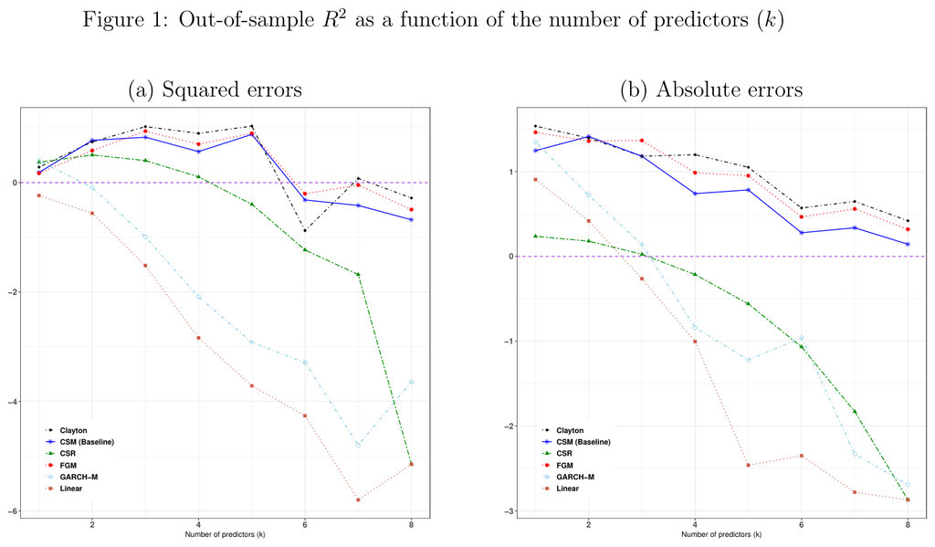

rebuilt from free data

A plot of Table 3's R-squared values against k. Every point in it is a cell scored above, so the figure carries no number of its own.

```python
show('F1', note="A plot of Table 3's R-squared values against k. Every point in it is a cell scored above, so the figure carries no number of its own.")
```

### Figure 2

*Figure 2: Wealth growth for the CSM (Baseline, k = 3), buy-and-hold, and momentum strategies*

**No rebuilt column.** A wealth-growth plot. Its endpoints are Table 6's terminal wealth, scored above; the path between them is never printed as numbers.

as the paper printed it

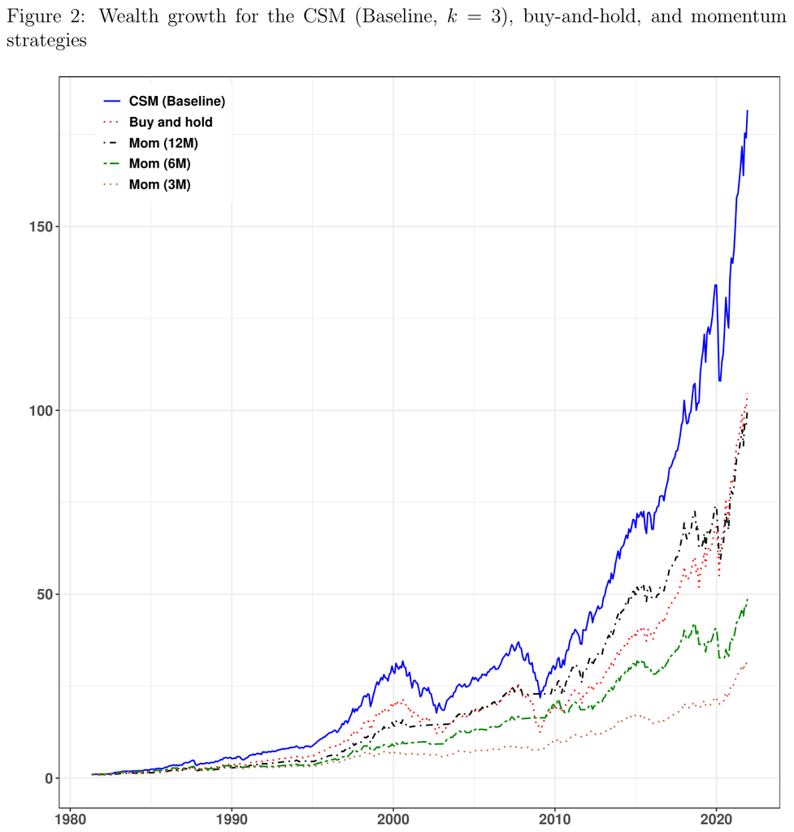

rebuilt from free data

A wealth-growth plot. Its endpoints are Table 6's terminal wealth, scored above; the path between them is never printed as numbers.

```python
show('F2', note="A wealth-growth plot. Its endpoints are Table 6's terminal wealth, scored above; the path between them is never printed as numbers.")
```

### Figure 3

*Figure 3: Wealth growth for the CSM (Baseline), copula-based, GARCH-M, CSR, and linear strategies, each with k = 3*

**No rebuilt column.** As Figure 2, across the copula and benchmark strategies.

as the paper printed it

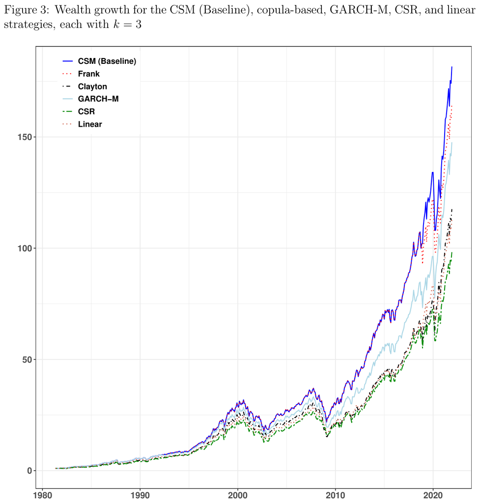

rebuilt from free data

As Figure 2, across the copula and benchmark strategies.

```python
show('F3', note='As Figure 2, across the copula and benchmark strategies.')
```

### Figure 4

*Figure 4: Terminal wealth as a function of the number of predictors (k) for CSM (Baseline), Clayton, GARCH-M, CSR, and linear models*

**No rebuilt column.** A plot of terminal wealth against k. Every point is a cell of Table 6 or B1, both scored above.

as the paper printed it

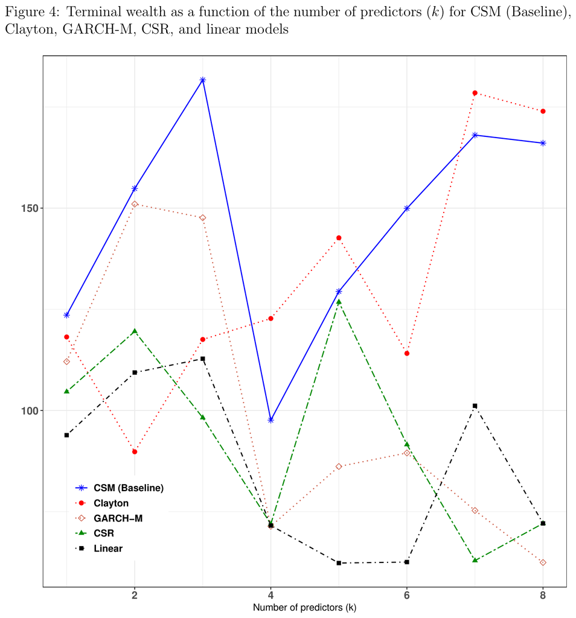

rebuilt from free data

A plot of terminal wealth against k. Every point is a cell of Table 6 or B1, both scored above.

```python
show('F4', note='A plot of terminal wealth against k. Every point is a cell of Table 6 or B1, both scored above.')
```

### Figure A1

*Figure A1: Out-of-sample R2 as a function of the number of predictors (k): MSE-based selection*

**No rebuilt column.** As Figure 1, for MSE-based selection.

as the paper printed it

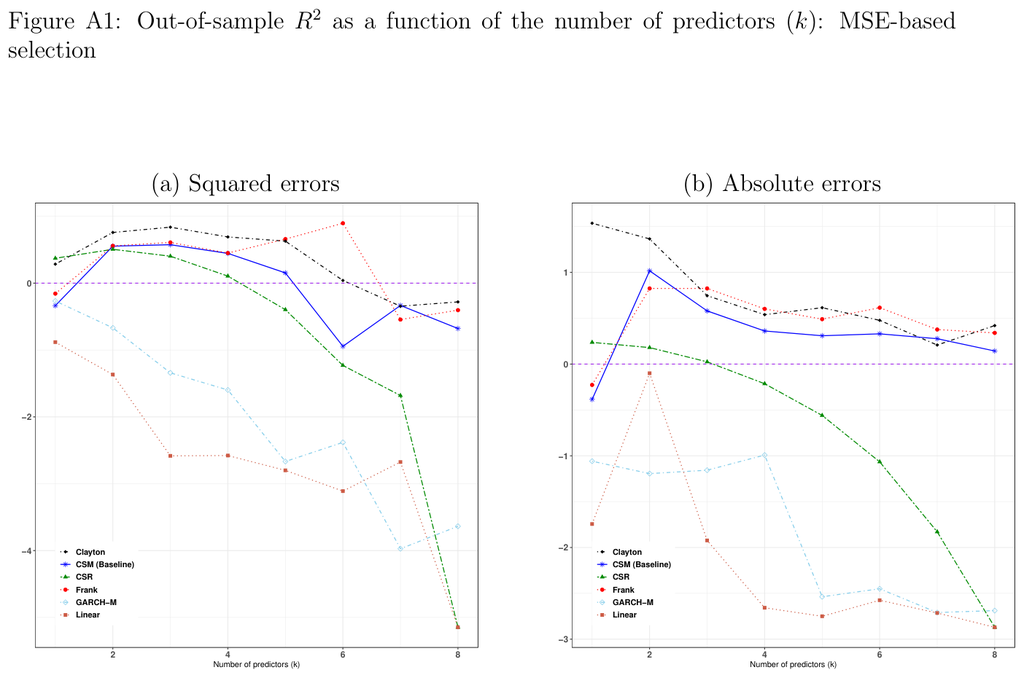

rebuilt from free data

As Figure 1, for MSE-based selection.

```python
show('FA1', note='As Figure 1, for MSE-based selection.')
```

### Figure C1

*Figure C1: Wealth growth during the Global Financial Crisis: 3-month momentum, CSR, GARCH-M, and buy-and-hold, together with the CSM (Baseline) and FGM copula strate- gies. The CSM (Baseline) and FGM wealth paths coincide and therefore overlap.*

**No rebuilt column.** The crisis wealth paths, whose endpoints are Table C1's terminal wealth.

as the paper printed it

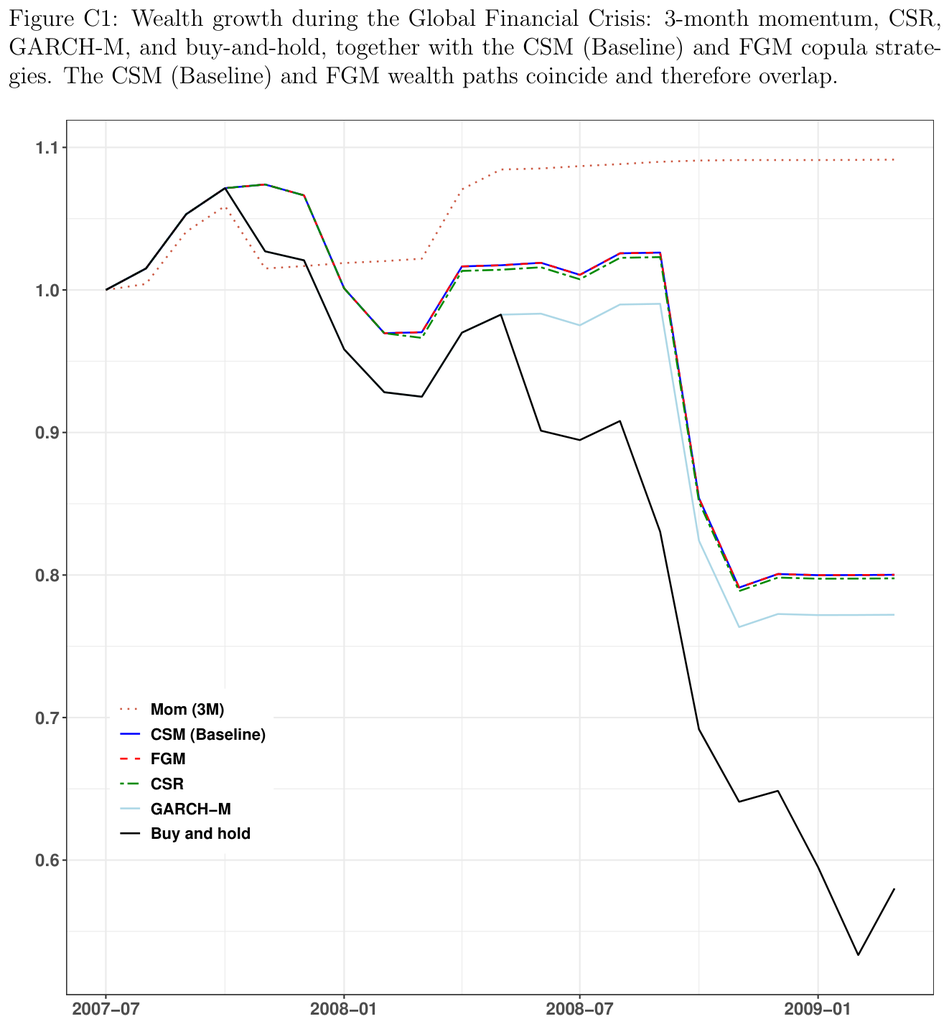

rebuilt from free data

The crisis wealth paths, whose endpoints are Table C1's terminal wealth.

```python
show('FC1', note="The crisis wealth paths, whose endpoints are Table C1's terminal wealth.")
```

### Figure C2

*Figure C2: Wealth growth during the COVID crisis period: 3-month momentum, CSM (Poly), FGM copula, CSR, GARCH-M, and buy-and-hold. The FGM and buy-and-hold wealth paths coincide, as do the CSR and CSM (Poly) paths, and the corresponding curves therefore overlap.*

**No rebuilt column.** As Figure C1, for the COVID window.

as the paper printed it

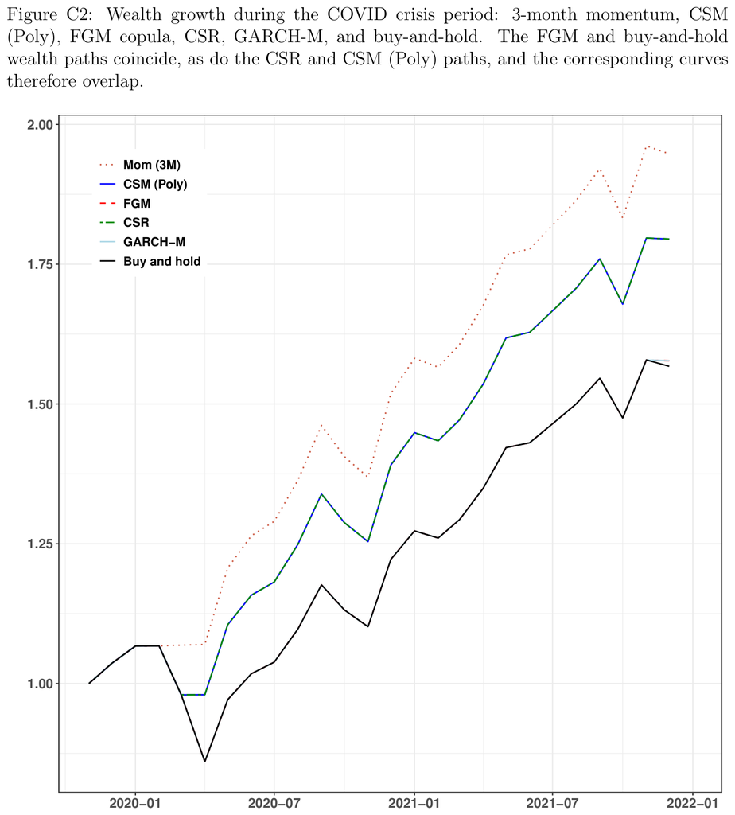

rebuilt from free data

As Figure C1, for the COVID window.

```python
show('FC2', note='As Figure C1, for the COVID window.')
```

### Figure D1

*Figure D1: Wealth growth for CSM (Baseline), copula-based (Clayton, Gaussian), CSR, and MS strategies with nine predictors (including momentum).*

**No rebuilt column.** The nine-predictor wealth paths, whose endpoints are Table D1's.

as the paper printed it

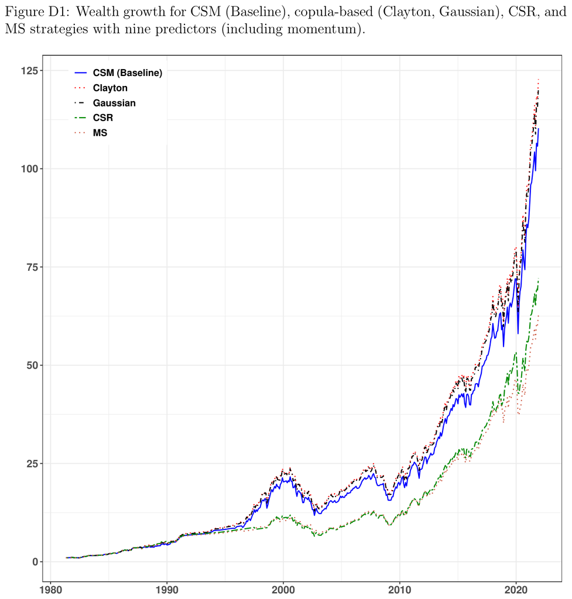

rebuilt from free data

The nine-predictor wealth paths, whose endpoints are Table D1's.

```python
show('FD1', note="The nine-predictor wealth paths, whose endpoints are Table D1's.")
```

### Table 1

*Table 1: Sample correlations*

as the paper printed it

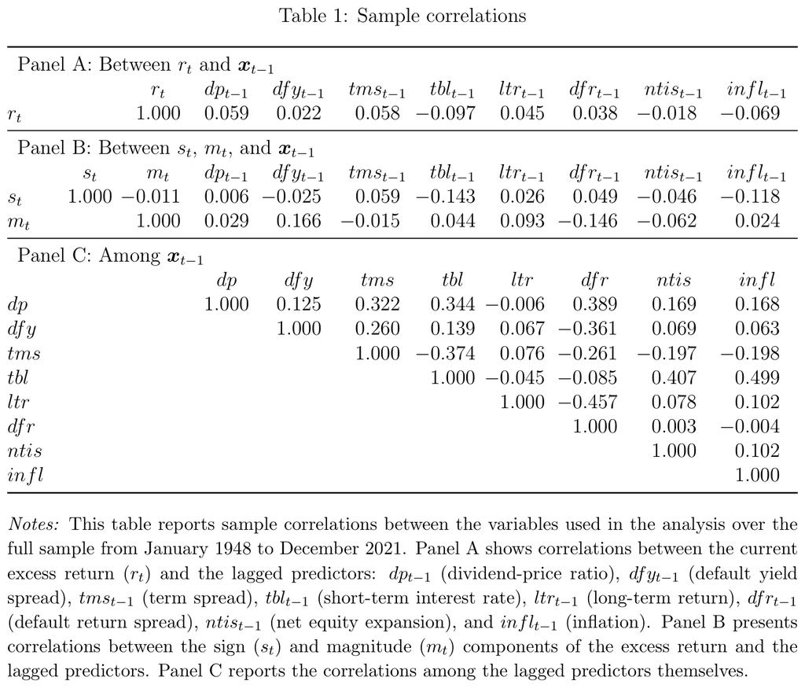

rebuilt from free data

| row | metric | printed | ours | gap | state |
| --- | --- | --- | --- | --- | --- |
| Panel A: Between r and x, r | r | 1 | 1 | 0 | match |
| Panel A: Between r and x, r | dp | 0.059 | 0.059159 | 0.000159 | match |
| Panel A: Between r and x, r | dfy | 0.022 | 0.022309 | 0.000309 | match |
| Panel A: Between r and x, r | tms | 0.058 | 0.057274 | 0.000726 | differs |
| Panel A: Between r and x, r | tbl | -0.097 | -0.097924 | 0.000924 | differs |
| Panel A: Between r and x, r | ltr | 0.045 | 0.084592 | 0.039592 | differs |
| Panel A: Between r and x, r | dfr | 0.038 | 0.037931 | 6.9e-05 | match |
| Panel A: Between r and x, r | ntis | -0.018 | -0.01715 | 0.00085 | differs |
| Panel A: Between r and x, r | infl | -0.069 | -0.068657 | 0.000343 | match |
| Panel B: Between s , m , and x, s | s | 1 | 1 | 0 | match |
| Panel B: Between s , m , and x, s | m | -0.011 | -0.010806 | 0.000194 | match |
| Panel B: Between s , m , and x, s | dp | 0.006 | 0.005625 | 0.000375 | match |
| Panel B: Between s , m , and x, s | dfy | -0.025 | -0.024614 | 0.000386 | match |
| Panel B: Between s , m , and x, s | tms | 0.059 | 0.058898 | 0.000102 | match |

showing 14 of 64 cells; the rest are in the artifact file.

T1: 39 matched, 25 differ, 0 not built.

```
def correlations(frame: pd.DataFrame) -> dict[str, float]:
    """Table 1, all three panels, over the whole 887-month sample (p.11).

    The decomposition is the paper's own: r is the raw excess return, s its
    sign and m its magnitude, each correlated against predictors already lagged
    one month by `load`. Panel C is the predictor block on its own, printed as
    an upper triangle, so only the cells the page actually fills are emitted.
    """
    r = frame["xs"].to_numpy()
    s = (r > 0).astype(float)
    m = np.abs(r)
    x = {p: frame[p].to_numpy() for p in PREDICTORS}

    def rho(a: np.ndarray, b: np.ndarray) -> float:
        return float(np.corrcoef(a, b)[0, 1])

    out: dict[str, float] = {}

    pa = "T1/Panel A: Between r and x"
    out[f"{pa}/r/r"] = 1.0
    for p in PREDICTORS:
        out[f"{pa}/r/{p}"] = rho(r, x[p])

    pb = "T1/Panel B: Between s , m , and x"
    series = {"s": s, "m": m}
    out[f"{pb}/s/s"] = 1.0
    out[f"{pb}/s/m"] = rho(s, m)
    out[f"{pb}/m/m"] = 1.0
    for row, values in series.items():
        for p in PREDICTORS:
            out[f"{pb}/{row}/{p}"] = rho(values, x[p])

    # Panel C prints the upper triangle only: the cell below the diagonal is
    # the same number and the page leaves it blank, so writing it would invent
    # an address the paper never used.
    pc = "T1/Panel C: Among x"
    for i, a in enumerate(PREDICTORS):
        out[f"{pc}/{a}/{a}"] = 1.0
        for b in PREDICTORS[i + 1:]:
            out[f"{pc}/{a}/{b}"] = rho(x[a], x[b])
    return out
```

```python
show('T1')

source('decomp2026_eval', 'correlations')
```

### Table 2

*Table 2: Best subset selection based on AUC criterion*

as the paper printed it

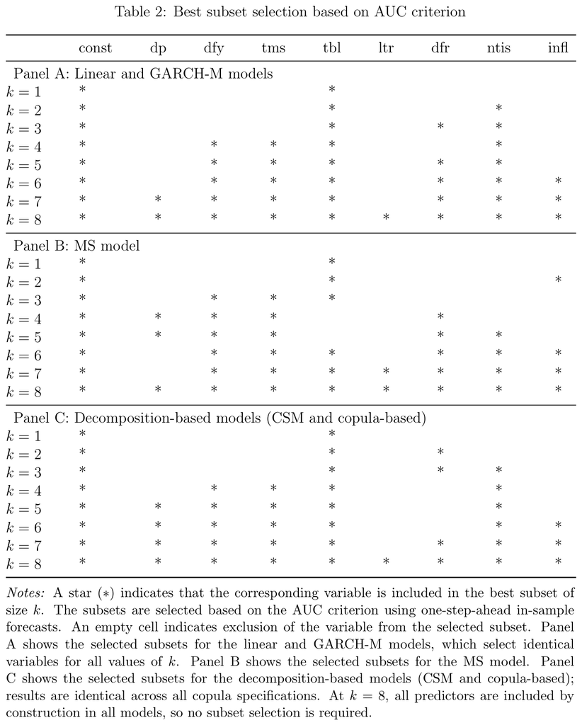

rebuilt from free data

A grid of asterisks marking which predictors each model selected at each k. Our own selections are printed below it, but the checklist harvested no numeric cells from the page, so there is nothing to score against.

```python
show('T2', note='A grid of asterisks marking which predictors each model selected at each k. Our own selections are printed below it, but the checklist harvested no numeric cells from the page, so there is nothing to score against.')
```

### Table 3

*Table 3: Out-of-sample R2 values by subset size (k) and loss function*

as the paper printed it

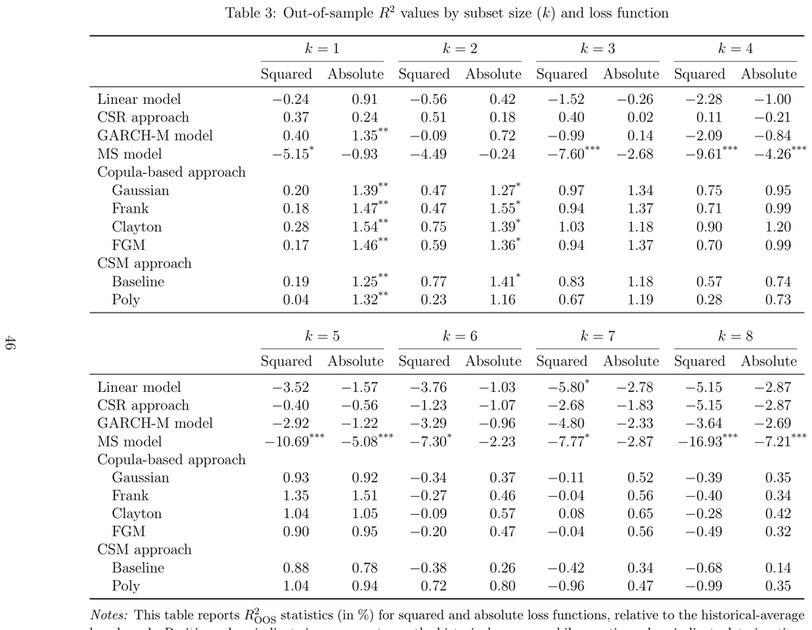

rebuilt from free data

[output not shown]

showing 14 of 128 cells; the rest are in the artifact file.

```
def r2_oos(actual: np.ndarray, model: np.ndarray, benchmark: np.ndarray,
           absolute: bool = False) -> float:
    """Campbell-Thompson R2 against the rolling historical average, in percent."""
    em, eb = actual - model, actual - benchmark
    loss = (np.abs if absolute else np.square)
    return float(100.0 * (1.0 - loss(em).sum() / loss(eb).sum()))
```

```python
show('T3')

source('decomp2026_eval', 'r2_oos')
```

### Table 4

*Table 4: Out-of-sample model performance comparison using MCS procedure with squared loss*

as the paper printed it

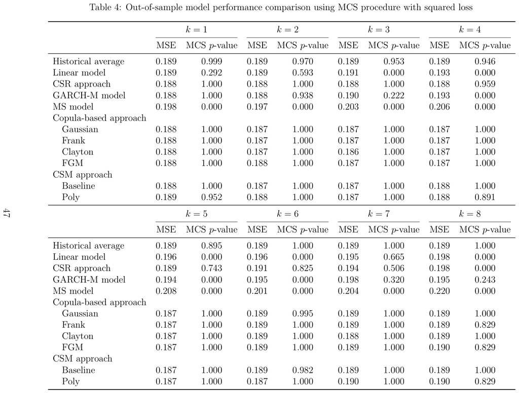

rebuilt from free data

| row | metric | printed | ours | gap | state |
| --- | --- | --- | --- | --- | --- |
| Historical average, k = 1 | MSE | 0.189 | 0.188603 | 0.000397 | match |
| Historical average, k = 1 | MCS p-value | 0.999 | 0.8746 | 0.1244 | differs |
| Historical average, k = 2 | MSE | 0.189 | 0.188603 | 0.000397 | match |
| Historical average, k = 2 | MCS p-value | 0.97 | 0.837 | 0.133 | differs |
| Historical average, k = 3 | MSE | 0.189 | 0.188603 | 0.000397 | match |
| Historical average, k = 3 | MCS p-value | 0.953 | 0.8394 | 0.1136 | differs |
| Historical average, k = 4 | MSE | 0.189 | 0.188603 | 0.000397 | match |
| Historical average, k = 4 | MCS p-value | 0.946 | 0.8638 | 0.0822 | differs |
| Linear model, k = 1 | MSE | 0.189 | 0.189047 | 4.7e-05 | match |
| Linear model, k = 1 | MCS p-value | 0.292 | 0.4956 | 0.2036 | differs |
| Linear model, k = 2 | MSE | 0.189 | 0.189656 | 0.000656 | differs |
| Linear model, k = 2 | MCS p-value | 0.593 | 0.8064 | 0.2134 | differs |
| Linear model, k = 3 | MSE | 0.191 | 0.191463 | 0.000463 | match |
| Linear model, k = 3 | MCS p-value | 0 | 0.5672 | 0.5672 | differs |

showing 14 of 144 cells; the rest are in the artifact file.

T4: 49 matched, 95 differ, 32 not built.

```
def mcs_pvalues(losses: dict[str, np.ndarray], boot: int = 5000,
                block: int = 2, seed: int = 20260204) -> dict[str, float]:
    """Hansen, Lunde and Nason (2011), the T_max variant of Section 3.1.2.

    The paper reports p-values from the R MCS package and states neither the
    block length nor the number of replications, so the package's own defaults
    are used and recorded as an assumption. The seed is fixed because a p-value
    that moves between runs cannot be scored against a printed one.
    """
    names = list(losses)
    L = np.column_stack([losses[n] for n in names])
    n, m = L.shape
    rng = np.random.default_rng(seed)

    # Stationary bootstrap indices, shared across models so the resampling
    # cannot favour one of them.
    idx = np.empty((boot, n), dtype=np.int64)
    for b in range(boot):
        i, pos = rng.integers(0, n), 0
        while pos < n:
            run = min(rng.geometric(1.0 / block), n - pos)
            take = (np.arange(i, i + run) % n)
            idx[b, pos:pos + run] = take
            pos += run
            i = rng.integers(0, n)

    alive = list(range(m))
    pvals: dict[str, float] = {}
    running = 0.0
    while len(alive) > 1:
        sub = L[:, alive]
        d = sub - sub.mean(axis=1, keepdims=True)   # loss vs the live average
        dbar = d.mean(axis=0)
        boot_mean = d[idx].mean(axis=1)             # (boot, alive)
        var = boot_mean.var(axis=0, ddof=1)
        var = np.where(var < 1e-18, 1e-18, var)
        tstat = dbar / np.sqrt(var)
        tboot = (boot_mean - dbar) / np.sqrt(var)

        tmax, tmax_boot = tstat.max(), tboot.max(axis=1)
        p = float((tmax_boot >= tmax).mean())
        running = max(running, p)

        worst = int(np.argmax(tstat))
        pvals[names[alive[worst]]] = running
        alive.pop(worst)

    pvals[names[alive[0]]] = 1.0
    return pvals
```

```python
show('T4')

source('decomp2026_eval', 'mcs_pvalues')
```

### Table 5

*Table 5: Out-of-sample model performance comparison using MCS procedure with absolute loss*

as the paper printed it

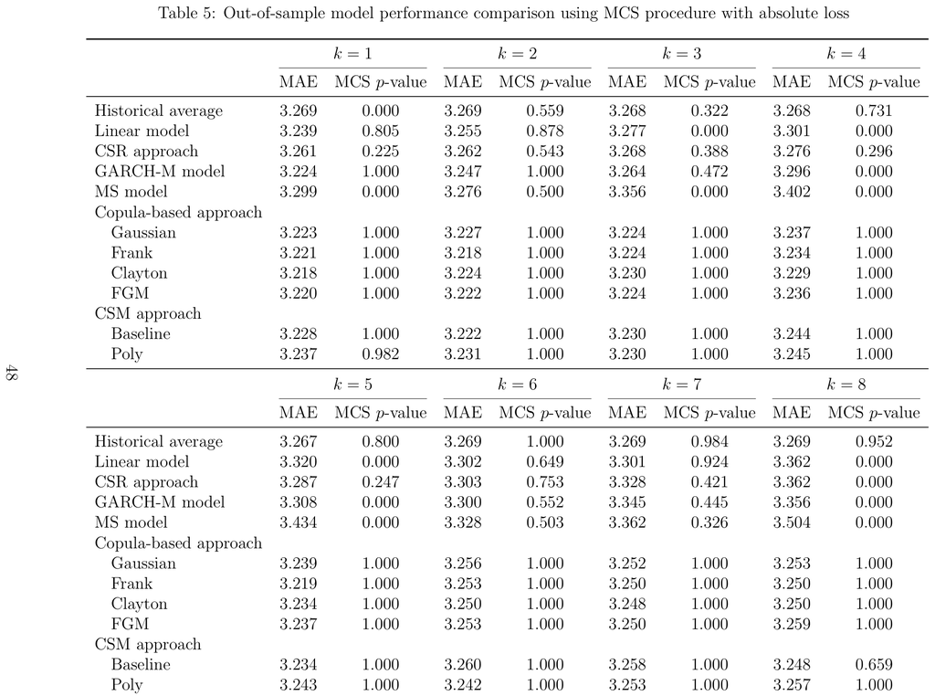

rebuilt from free data

| row | metric | printed | ours | gap | state |
| --- | --- | --- | --- | --- | --- |
| Historical average, k = 1 | MAE | 3.269 | 3.26864 | 0.000362 | match |
| Historical average, k = 1 | MCS p-value | 0 | 0.0758 | 0.0758 | differs |
| Historical average, k = 2 | MAE | 3.269 | 3.26864 | 0.000362 | match |
| Historical average, k = 2 | MCS p-value | 0.559 | 0.231 | 0.328 | differs |
| Historical average, k = 3 | MAE | 3.268 | 3.26864 | 0.000638 | differs |
| Historical average, k = 3 | MCS p-value | 0.322 | 0.3444 | 0.0224 | differs |
| Historical average, k = 4 | MAE | 3.268 | 3.26864 | 0.000638 | differs |
| Historical average, k = 4 | MCS p-value | 0.731 | 0.3098 | 0.4212 | differs |
| Linear model, k = 1 | MAE | 3.239 | 3.23903 | 2.8e-05 | match |
| Linear model, k = 1 | MCS p-value | 0.805 | 0.1834 | 0.6216 | differs |
| Linear model, k = 2 | MAE | 3.255 | 3.25496 | 4.2e-05 | match |
| Linear model, k = 2 | MCS p-value | 0.878 | 0.5182 | 0.3598 | differs |
| Linear model, k = 3 | MAE | 3.277 | 3.27725 | 0.000247 | match |
| Linear model, k = 3 | MCS p-value | 0 | 0.3444 | 0.3444 | differs |

showing 14 of 144 cells; the rest are in the artifact file.

T5: 29 matched, 115 differ, 32 not built.

```
def mcs_pvalues(losses: dict[str, np.ndarray], boot: int = 5000,
                block: int = 2, seed: int = 20260204) -> dict[str, float]:
    """Hansen, Lunde and Nason (2011), the T_max variant of Section 3.1.2.

    The paper reports p-values from the R MCS package and states neither the
    block length nor the number of replications, so the package's own defaults
    are used and recorded as an assumption. The seed is fixed because a p-value
    that moves between runs cannot be scored against a printed one.
    """
    names = list(losses)
    L = np.column_stack([losses[n] for n in names])
    n, m = L.shape
    rng = np.random.default_rng(seed)

    # Stationary bootstrap indices, shared across models so the resampling
    # cannot favour one of them.
    idx = np.empty((boot, n), dtype=np.int64)
    for b in range(boot):
        i, pos = rng.integers(0, n), 0
        while pos < n:
            run = min(rng.geometric(1.0 / block), n - pos)
            take = (np.arange(i, i + run) % n)
            idx[b, pos:pos + run] = take
            pos += run
            i = rng.integers(0, n)

    alive = list(range(m))
    pvals: dict[str, float] = {}
    running = 0.0
    while len(alive) > 1:
        sub = L[:, alive]
        d = sub - sub.mean(axis=1, keepdims=True)   # loss vs the live average
        dbar = d.mean(axis=0)
        boot_mean = d[idx].mean(axis=1)             # (boot, alive)
        var = boot_mean.var(axis=0, ddof=1)
        var = np.where(var < 1e-18, 1e-18, var)
        tstat = dbar / np.sqrt(var)
        tboot = (boot_mean - dbar) / np.sqrt(var)

        tmax, tmax_boot = tstat.max(), tboot.max(axis=1)
        p = float((tmax_boot >= tmax).mean())
        running = max(running, p)

        worst = int(np.argmax(tstat))
        pvals[names[alive[worst]]] = running
        alive.pop(worst)

    pvals[names[alive[0]]] = 1.0
    return pvals
```

```python
show('T5')

source('decomp2026_eval', 'mcs_pvalues')
```

### Table 6

*Table 6: Out-of-sample performance statistics for the trading strategies for k = 1, 2, 3, 7*

as the paper printed it

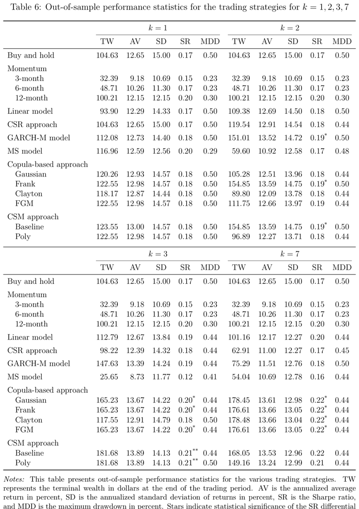

rebuilt from free data

| row | metric | printed | ours | gap | state |
| --- | --- | --- | --- | --- | --- |
| Buy and hold, k =1 | TW | 104.63 | 104.625 | 0.005322 | differs |
| Buy and hold, k =1 | AV | 12.65 | 12.6489 | 0.001071 | match |
| Buy and hold, k =1 | SD | 15 | 14.9972 | 0.002838 | match |
| Buy and hold, k =1 | SR | 0.17 | 0.172235 | 0.002235 | match |
| Buy and hold, k =1 | MDD | 0.5 | 0.502159 | 0.002159 | match |
| Buy and hold, k =2 | TW | 104.63 | 104.625 | 0.005322 | differs |
| Buy and hold, k =2 | AV | 12.65 | 12.6489 | 0.001071 | match |
| Buy and hold, k =2 | SD | 15 | 14.9972 | 0.002838 | match |
| Buy and hold, k =2 | SR | 0.17 | 0.172235 | 0.002235 | match |
| Buy and hold, k =2 | MDD | 0.5 | 0.502159 | 0.002159 | match |
| Momentum, 3-month, k =1 | TW | 32.39 | 40.4935 | 8.10346 | differs |
| Momentum, 3-month, k =1 | AV | 9.18 | 10.0652 | 0.885221 | differs |
| Momentum, 3-month, k =1 | SD | 10.69 | 11.2758 | 0.585761 | differs |
| Momentum, 3-month, k =1 | SR | 0.15 | 0.162932 | 0.012932 | differs |

showing 14 of 240 cells; the rest are in the artifact file.

T6: 85 matched, 155 differ, 40 not built.

```
def switching(forecast: np.ndarray, mkt: np.ndarray, rf: np.ndarray) -> dict:
    """The paper's switching rule, and everything Table 6 reports about it."""
    equity = forecast > 0
    ret = np.where(equity, mkt, rf)

    # Nothing is held before the first decision, so the first allocation is not
    # a switch. Charging it would put a cost on buy-and-hold, whose printed
    # 104.63 is exactly the uncosted compounding of the index.
    switched = np.empty(len(equity), dtype=bool)
    switched[0] = False
    switched[1:] = equity[1:] != equity[:-1]

    wealth = np.cumprod((1.0 + ret) * np.where(switched, 1.0 - COST, 1.0))
    peak = np.maximum.accumulate(wealth)
    return {
        "returns": ret,
        "excess": ret - rf,
        "wealth": wealth,
        "TW": float(wealth[-1]),
        "AV": float(ret.mean() * MONTHS * 100.0),
        "SD": float(ret.std(ddof=1) * np.sqrt(MONTHS) * 100.0),
        "SR": float((ret - rf).mean() / ret.std(ddof=1)),
        "MDD": float(np.max(1.0 - wealth / peak)),
        "switches": int(switched.sum()),
    }
```

```python
show('T6')

source('decomp2026_eval', 'switching')
```

### Table 7

*Table 7: CER gains against historical average for γ = 5*

as the paper printed it

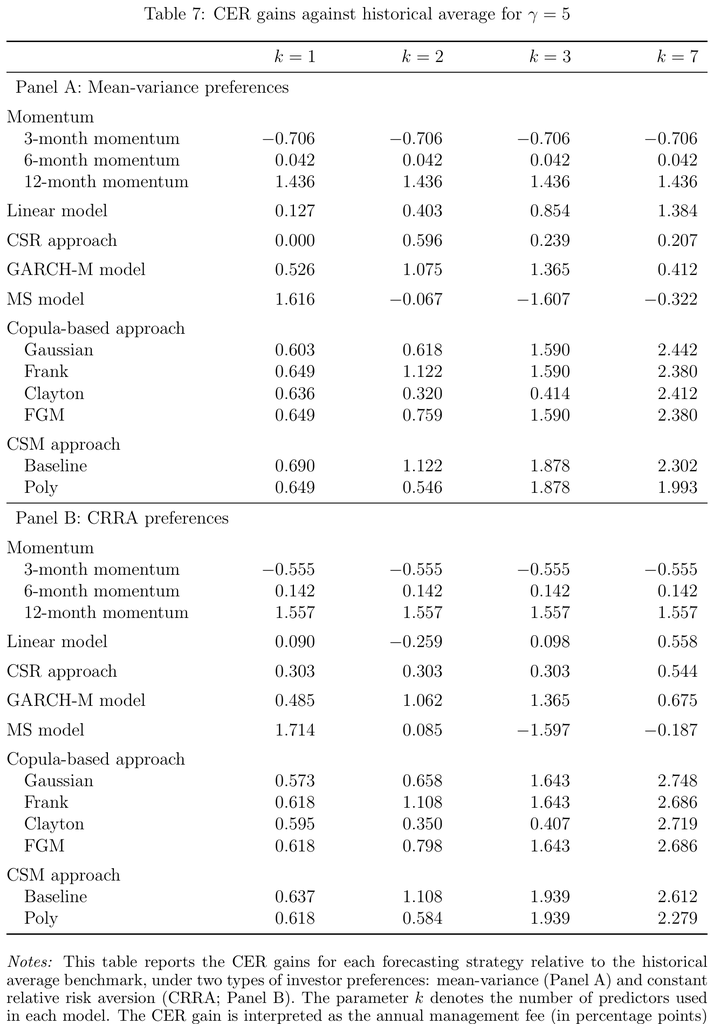

rebuilt from free data

| row | metric | printed | ours | gap | state |
| --- | --- | --- | --- | --- | --- |
| Panel A: Mean-variance preferences, 3-month momentum | k = 1 | -0.706 | -0.139406 | 0.566594 | differs |
| Panel A: Mean-variance preferences, 3-month momentum | k = 2 | -0.706 | -0.139406 | 0.566594 | differs |
| Panel A: Mean-variance preferences, 3-month momentum | k = 3 | -0.706 | -0.139406 | 0.566594 | differs |
| Panel A: Mean-variance preferences, 3-month momentum | k = 7 | -0.706 | -0.139406 | 0.566594 | differs |
| Panel A: Mean-variance preferences, 6-month momentum | k = 1 | 0.042 | 0.053899 | 0.011899 | differs |
| Panel A: Mean-variance preferences, 6-month momentum | k = 2 | 0.042 | 0.053899 | 0.011899 | differs |
| Panel A: Mean-variance preferences, 6-month momentum | k = 3 | 0.042 | 0.053899 | 0.011899 | differs |
| Panel A: Mean-variance preferences, 6-month momentum | k = 7 | 0.042 | 0.053899 | 0.011899 | differs |
| Panel A: Mean-variance preferences, 12-month momentum | k = 1 | 1.436 | 1.04674 | 0.389261 | differs |
| Panel A: Mean-variance preferences, 12-month momentum | k = 2 | 1.436 | 1.04674 | 0.389261 | differs |
| Panel A: Mean-variance preferences, 12-month momentum | k = 3 | 1.436 | 1.04674 | 0.389261 | differs |
| Panel A: Mean-variance preferences, 12-month momentum | k = 7 | 1.436 | 1.04674 | 0.389261 | differs |
| Panel A: Mean-variance preferences, Linear model | k = 1 | 0.127 | 0.133525 | 0.006525 | differs |
| Panel A: Mean-variance preferences, Linear model | k = 2 | 0.403 | 0.436272 | 0.033272 | differs |

showing 14 of 88 cells; the rest are in the artifact file.

T7: 1 matched, 87 differ, 16 not built.

```
def cer_mean_variance(ret: np.ndarray) -> float:
    return float(ret.mean() - 0.5 * GAMMA * ret.var(ddof=1))
```

```python
show('T7')

source('decomp2026_eval', 'cer_mean_variance')
```

### Table 8

*Table 8: CER gains against CSM (Baseline) for γ = 5*

as the paper printed it

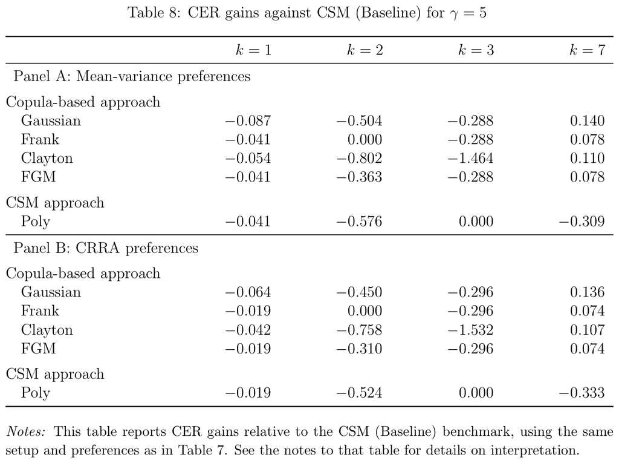

rebuilt from free data

| row | metric | printed | ours | gap | state |
| --- | --- | --- | --- | --- | --- |
| Panel A: Mean-variance preferences, Gaussian | k = 1 | -0.087 | 0 | 0.087 | differs |
| Panel A: Mean-variance preferences, Gaussian | k = 2 | -0.504 | 0.061443 | 0.565443 | differs |
| Panel A: Mean-variance preferences, Gaussian | k = 3 | -0.288 | 0.109036 | 0.397036 | differs |
| Panel A: Mean-variance preferences, Gaussian | k = 7 | 0.14 | -0.096734 | 0.236734 | differs |
| Panel A: Mean-variance preferences, Frank | k = 1 | -0.041 | -3.72309 | 3.68209 | differs |
| Panel A: Mean-variance preferences, Frank | k = 2 | 0 | -4.87855 | 4.87855 | differs |
| Panel A: Mean-variance preferences, Frank | k = 3 | -0.288 | -5.13903 | 4.85103 | differs |
| Panel A: Mean-variance preferences, Frank | k = 7 | 0.078 | -7.88892 | 7.96692 | differs |
| Panel A: Mean-variance preferences, Clayton | k = 1 | -0.054 | 0.053685 | 0.107685 | differs |
| Panel A: Mean-variance preferences, Clayton | k = 2 | -0.802 | 0.047986 | 0.849986 | differs |
| Panel A: Mean-variance preferences, Clayton | k = 3 | -1.464 | 0.109036 | 1.57304 | differs |
| Panel A: Mean-variance preferences, Clayton | k = 7 | 0.11 | -0.188172 | 0.298172 | differs |
| Panel A: Mean-variance preferences, FGM | k = 1 | -0.041 | 0 | 0.041 | differs |
| Panel A: Mean-variance preferences, FGM | k = 2 | -0.363 | 0.061443 | 0.424443 | differs |

showing 14 of 40 cells; the rest are in the artifact file.

T8: 0 matched, 40 differ, 0 not built.

```
def cer_crra(ret: np.ndarray) -> float:
    power = np.power(1.0 + ret, 1.0 - GAMMA)
    return float(np.mean(power) ** (1.0 / (1.0 - GAMMA)) - 1.0)
```

```python
show('T8')

source('decomp2026_eval', 'cer_crra')
```

### Table A1

*Table A1: Best subset selection based on MSE criterion*

**No rebuilt column.** As Table 2, for MSE-based selection rather than AUC.

as the paper printed it

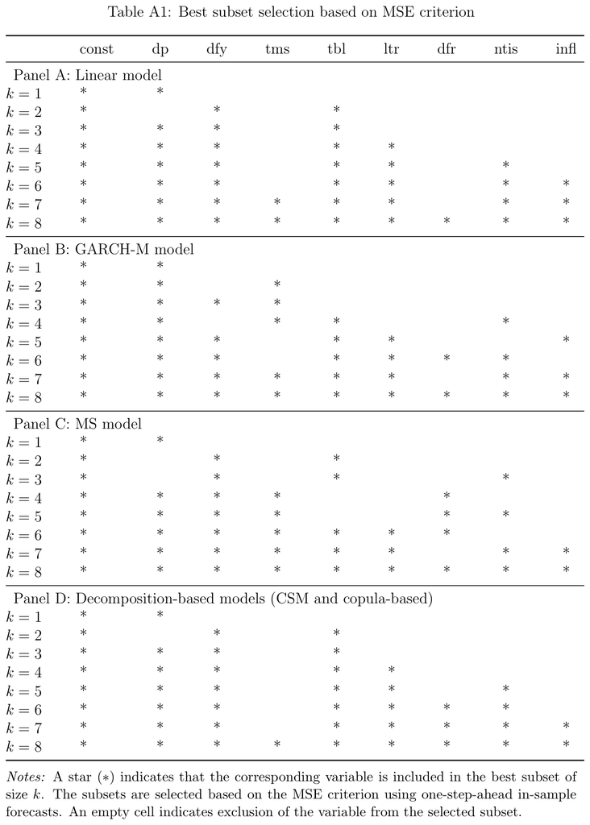

rebuilt from free data

As Table 2, for MSE-based selection rather than AUC.

```python
show('TA1', note='As Table 2, for MSE-based selection rather than AUC.')
```

### Table A2

*Table A2: Out-of-sample R2 values (in %) for different models, loss functions, and subset sizes (k)*

**No rebuilt column.** This prints out-of-sample R-squared by model, loss and k, which is what Table 3 prints, and the two disagree: the linear model at k = 1 under squared loss is -0.24 in Table 3 and -0.88 here. Neither caption says what changed between them, so there is no way to know which one a replication should be scored against. Recorded rather than guessed.

as the paper printed it

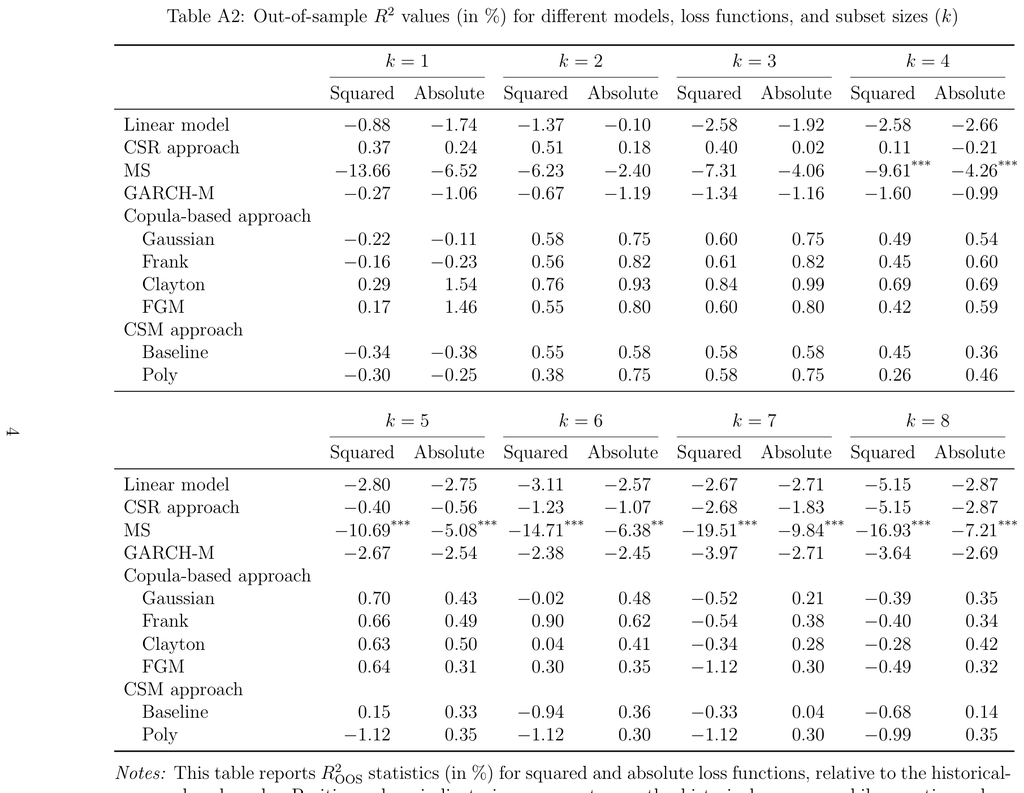

rebuilt from free data

| row | metric | printed | ours | gap | state |
| --- | --- | --- | --- | --- | --- |
| Linear model, k = 1 | Squared | -0.88 | — | — | not built |
| Linear model, k = 1 | Absolute | -1.74 | — | — | not built |
| Linear model, k = 2 | Squared | -1.37 | — | — | not built |
| Linear model, k = 2 | Absolute | -0.1 | — | — | not built |
| Linear model, k = 3 | Squared | -2.58 | — | — | not built |
| Linear model, k = 3 | Absolute | -1.92 | — | — | not built |
| Linear model, k = 4 | Squared | -2.58 | — | — | not built |
| Linear model, k = 4 | Absolute | -2.66 | — | — | not built |
| CSR approach, k = 1 | Squared | 0.37 | — | — | not built |
| CSR approach, k = 1 | Absolute | 0.24 | — | — | not built |
| CSR approach, k = 2 | Squared | 0.51 | — | — | not built |
| CSR approach, k = 2 | Absolute | 0.18 | — | — | not built |
| CSR approach, k = 3 | Squared | 0.4 | — | — | not built |
| CSR approach, k = 3 | Absolute | 0.02 | — | — | not built |

showing 14 of 160 cells; the rest are in the artifact file.

TA2: 0 matched, 0 differ, 160 not built.

```python
show('TA2', note='This prints out-of-sample R-squared by model, loss and k, which is what Table 3 prints, and the two disagree: the linear model at k = 1 under squared loss is -0.24 in Table 3 and -0.88 here. Neither caption says what changed between them, so there is no way to know which one a replication should be scored against. Recorded rather than guessed.')
```

### Table B1

*Table B1: Out-of-sample performance statistics for the trading strategies for k = 4, 5, 6, 8*

as the paper printed it

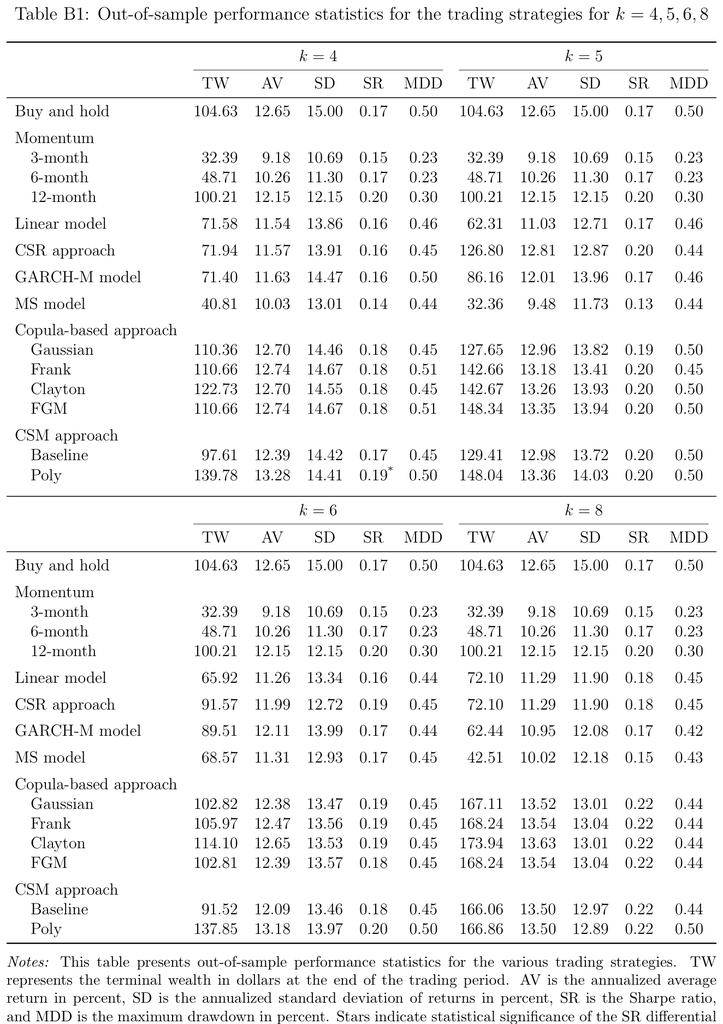

rebuilt from free data

| row | metric | printed | ours | gap | state |
| --- | --- | --- | --- | --- | --- |
| Buy and hold, k =4 | TW | 104.63 | 104.625 | 0.005322 | differs |
| Buy and hold, k =4 | AV | 12.65 | 12.6489 | 0.001071 | match |
| Buy and hold, k =4 | SD | 15 | 14.9972 | 0.002838 | match |
| Buy and hold, k =4 | SR | 0.17 | 0.172235 | 0.002235 | match |
| Buy and hold, k =4 | MDD | 0.5 | 0.502159 | 0.002159 | match |
| Buy and hold, k =5 | TW | 104.63 | 104.625 | 0.005322 | differs |
| Buy and hold, k =5 | AV | 12.65 | 12.6489 | 0.001071 | match |
| Buy and hold, k =5 | SD | 15 | 14.9972 | 0.002838 | match |
| Buy and hold, k =5 | SR | 0.17 | 0.172235 | 0.002235 | match |
| Buy and hold, k =5 | MDD | 0.5 | 0.502159 | 0.002159 | match |
| Momentum, 3-month, k =4 | TW | 32.39 | 40.4935 | 8.10346 | differs |
| Momentum, 3-month, k =4 | AV | 9.18 | 10.0652 | 0.885221 | differs |
| Momentum, 3-month, k =4 | SD | 10.69 | 11.2758 | 0.585761 | differs |
| Momentum, 3-month, k =4 | SR | 0.15 | 0.162932 | 0.012932 | differs |

showing 14 of 240 cells; the rest are in the artifact file.

TB1: 73 matched, 167 differ, 40 not built.

```
def switching(forecast: np.ndarray, mkt: np.ndarray, rf: np.ndarray) -> dict:
    """The paper's switching rule, and everything Table 6 reports about it."""
    equity = forecast > 0
    ret = np.where(equity, mkt, rf)

    # Nothing is held before the first decision, so the first allocation is not
    # a switch. Charging it would put a cost on buy-and-hold, whose printed
    # 104.63 is exactly the uncosted compounding of the index.
    switched = np.empty(len(equity), dtype=bool)
    switched[0] = False
    switched[1:] = equity[1:] != equity[:-1]

    wealth = np.cumprod((1.0 + ret) * np.where(switched, 1.0 - COST, 1.0))
    peak = np.maximum.accumulate(wealth)
    return {
        "returns": ret,
        "excess": ret - rf,
        "wealth": wealth,
        "TW": float(wealth[-1]),
        "AV": float(ret.mean() * MONTHS * 100.0),
        "SD": float(ret.std(ddof=1) * np.sqrt(MONTHS) * 100.0),
        "SR": float((ret - rf).mean() / ret.std(ddof=1)),
        "MDD": float(np.max(1.0 - wealth / peak)),
        "switches": int(switched.sum()),
    }
```

```python
show('TB1')

source('decomp2026_eval', 'switching')
```

### Table B2

*Table B2: CER gains against historical average for γ = 5*

as the paper printed it

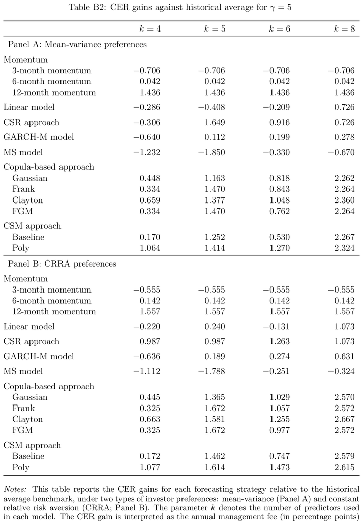

rebuilt from free data

| row | metric | printed | ours | gap | state |
| --- | --- | --- | --- | --- | --- |
| Panel A: Mean-variance preferences, 3-month momentum | k = 4 | -0.706 | -0.139406 | 0.566594 | differs |
| Panel A: Mean-variance preferences, 3-month momentum | k = 5 | -0.706 | -0.139406 | 0.566594 | differs |
| Panel A: Mean-variance preferences, 3-month momentum | k = 6 | -0.706 | -0.139406 | 0.566594 | differs |
| Panel A: Mean-variance preferences, 3-month momentum | k = 8 | -0.706 | -0.139406 | 0.566594 | differs |
| Panel A: Mean-variance preferences, 6-month momentum | k = 4 | 0.042 | 0.053899 | 0.011899 | differs |
| Panel A: Mean-variance preferences, 6-month momentum | k = 5 | 0.042 | 0.053899 | 0.011899 | differs |
| Panel A: Mean-variance preferences, 6-month momentum | k = 6 | 0.042 | 0.053899 | 0.011899 | differs |
| Panel A: Mean-variance preferences, 6-month momentum | k = 8 | 0.042 | 0.053899 | 0.011899 | differs |
| Panel A: Mean-variance preferences, 12-month momentum | k = 4 | 1.436 | 1.04674 | 0.389261 | differs |
| Panel A: Mean-variance preferences, 12-month momentum | k = 5 | 1.436 | 1.04674 | 0.389261 | differs |
| Panel A: Mean-variance preferences, 12-month momentum | k = 6 | 1.436 | 1.04674 | 0.389261 | differs |
| Panel A: Mean-variance preferences, 12-month momentum | k = 8 | 1.436 | 1.04674 | 0.389261 | differs |
| Panel A: Mean-variance preferences, Linear model | k = 4 | -0.286 | -0.228568 | 0.057432 | differs |
| Panel A: Mean-variance preferences, Linear model | k = 5 | -0.408 | -0.301732 | 0.106268 | differs |

showing 14 of 88 cells; the rest are in the artifact file.

TB2: 0 matched, 88 differ, 16 not built.

```
def cer_mean_variance(ret: np.ndarray) -> float:
    return float(ret.mean() - 0.5 * GAMMA * ret.var(ddof=1))
```

```python
show('TB2')

source('decomp2026_eval', 'cer_mean_variance')
```

### Table B3

*Table B3: CER gains against CSM (Baseline) for γ = 5*

as the paper printed it

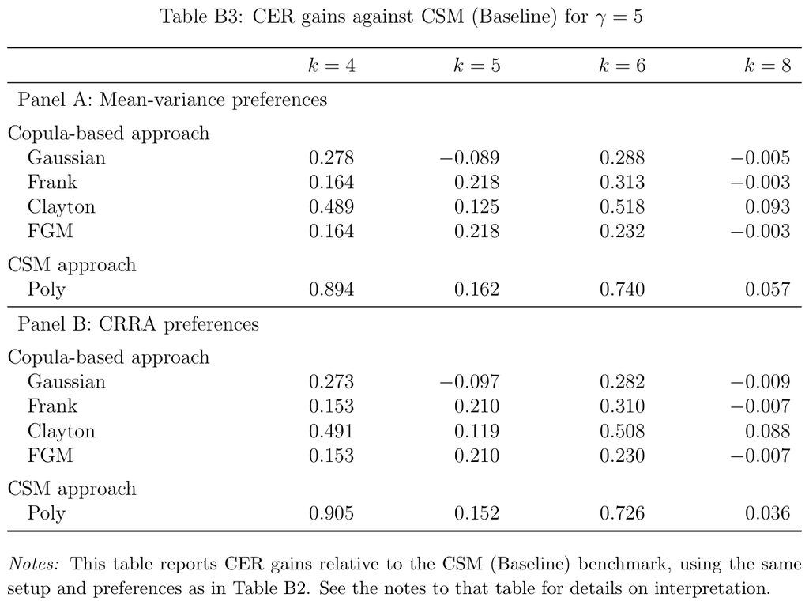

rebuilt from free data

| row | metric | printed | ours | gap | state |
| --- | --- | --- | --- | --- | --- |
| Panel A: Mean-variance preferences, Gaussian | k = 4 | 0.278 | -0.059498 | 0.337498 | differs |
| Panel A: Mean-variance preferences, Gaussian | k = 5 | -0.089 | 0.099374 | 0.188374 | differs |
| Panel A: Mean-variance preferences, Gaussian | k = 6 | 0.288 | 0.151372 | 0.136628 | differs |
| Panel A: Mean-variance preferences, Gaussian | k = 8 | -0.005 | -0.243159 | 0.238159 | differs |
| Panel A: Mean-variance preferences, Frank | k = 4 | 0.164 | -5.64433 | 5.80833 | differs |
| Panel A: Mean-variance preferences, Frank | k = 5 | 0.218 | -5.9311 | 6.14909 | differs |
| Panel A: Mean-variance preferences, Frank | k = 6 | 0.313 | -5.13598 | 5.44898 | differs |
| Panel A: Mean-variance preferences, Frank | k = 8 | -0.003 | -7.94814 | 7.94514 | differs |
| Panel A: Mean-variance preferences, Clayton | k = 4 | 0.489 | 0.251157 | 0.237843 | differs |
| Panel A: Mean-variance preferences, Clayton | k = 5 | 0.125 | 0.305593 | 0.180593 | differs |
| Panel A: Mean-variance preferences, Clayton | k = 6 | 0.518 | 0.319009 | 0.198991 | differs |
| Panel A: Mean-variance preferences, Clayton | k = 8 | 0.093 | 0.043016 | 0.049984 | differs |
| Panel A: Mean-variance preferences, FGM | k = 4 | 0.164 | 0.193323 | 0.029323 | differs |
| Panel A: Mean-variance preferences, FGM | k = 5 | 0.218 | 0.328646 | 0.110646 | differs |

showing 14 of 40 cells; the rest are in the artifact file.

TB3: 0 matched, 40 differ, 0 not built.

```
def cer_crra(ret: np.ndarray) -> float:
    power = np.power(1.0 + ret, 1.0 - GAMMA)
    return float(np.mean(power) ** (1.0 / (1.0 - GAMMA)) - 1.0)
```

```python
show('TB3')

source('decomp2026_eval', 'cer_crra')
```

### Table C1

*Table C1: Out-of-sample performance statistics for the trading strategies during crisis peri- ods*

as the paper printed it

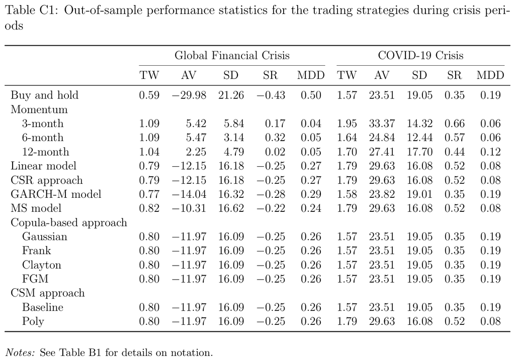

rebuilt from free data

| row | metric | printed | ours | gap | state |
| --- | --- | --- | --- | --- | --- |
| Buy and hold, Global Financial Crisis | TW | 0.59 | — | — | not built |
| Buy and hold, Global Financial Crisis | AV | -29.98 | — | — | not built |
| Buy and hold, Global Financial Crisis | SD | 21.26 | — | — | not built |
| Buy and hold, Global Financial Crisis | SR | -0.43 | — | — | not built |
| Buy and hold, Global Financial Crisis | MDD | 0.5 | — | — | not built |
| Buy and hold, COVID-19 Crisis | TW | 1.57 | — | — | not built |
| Buy and hold, COVID-19 Crisis | AV | 23.51 | — | — | not built |
| Buy and hold, COVID-19 Crisis | SD | 19.05 | — | — | not built |
| Buy and hold, COVID-19 Crisis | SR | 0.35 | — | — | not built |
| Buy and hold, COVID-19 Crisis | MDD | 0.19 | — | — | not built |
| Momentum, 3-month, Global Financial Crisis | TW | 1.09 | — | — | not built |
| Momentum, 3-month, Global Financial Crisis | AV | 5.42 | — | — | not built |
| Momentum, 3-month, Global Financial Crisis | SD | 5.84 | — | — | not built |
| Momentum, 3-month, Global Financial Crisis | SR | 0.17 | — | — | not built |

showing 14 of 140 cells; the rest are in the artifact file.

TC1: 0 matched, 0 differ, 140 not built.

```
def crisis_tables(frame: pd.DataFrame,
                  forecasts: dict[str, np.ndarray]) -> dict[str, float]:
    """Table C1: the same strategies, scored inside two named windows.

    The forecasts are the ones already produced for k = 8; re-estimating inside
    the crisis would be a different exercise from the one the appendix
    describes, which evaluates the main analysis over a sub-period.
    """
    oos = frame.iloc[WINDOW:]
    index = oos.index
    mkt, rf = oos["mkt"].to_numpy(), oos["rf"].to_numpy()

    rows: dict[str, np.ndarray] = {"Buy and hold": np.ones(len(mkt))}
    for n in MOMENTUM:
        rows[f"{n}-month"] = momentum_positions(frame, n)
    rows.update(forecasts)

    out: dict[str, float] = {}
    for name, (start, end) in CRISES.items():
        mask = (index >= start) & (index <= f"{end}-31")
        for row, signal in rows.items():
            if row == "Historical average":
                continue
            # Wealth restarts at $1 inside the window, so the slice is taken
            # before compounding rather than read off the full path.
            s = switching(signal[mask], mkt[mask], rf[mask])
            label = (f"TC1/Momentum/{row}" if row.endswith("-month")
                     else f"TC1/{row}")
            for metric in ("TW", "AV", "SD", "SR", "MDD"):
                out[f"{label}/{name}/{metric}"] = s[metric]
    return out
```

```python
show('TC1')

source('decomp2026_eval', 'crisis_tables')
```

### Table D1

*Table D1: Out-of-sample R2 and economic performance across models*

as the paper printed it

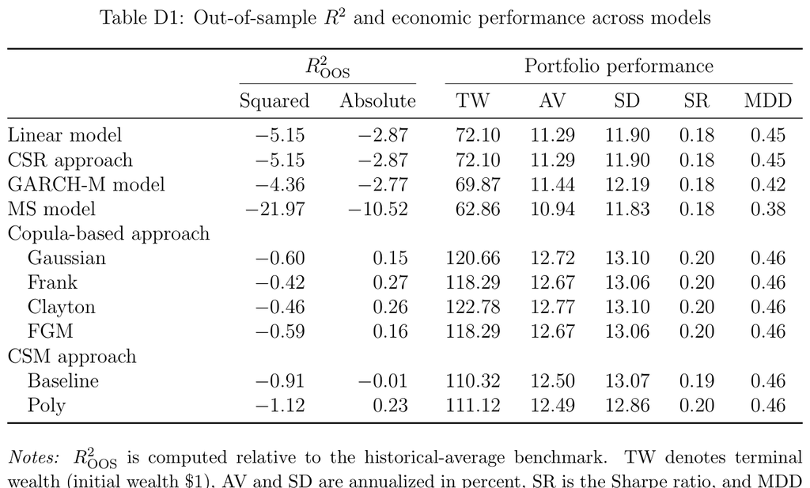

rebuilt from free data

| row | metric | printed | ours | gap | state |
| --- | --- | --- | --- | --- | --- |
| Linear model, OOS | Squared | -5.15 | — | — | not built |
| Linear model, OOS | Absolute | -2.87 | — | — | not built |
| Linear model, OOS | TW | 72.1 | — | — | not built |
| Linear model, OOS | AV | 11.29 | — | — | not built |
| Linear model, OOS | SD | 11.9 | — | — | not built |
| Linear model, OOS | SR | 0.18 | — | — | not built |
| Linear model, OOS | MDD | 0.45 | — | — | not built |
| CSR approach, OOS | Squared | -5.15 | — | — | not built |
| CSR approach, OOS | Absolute | -2.87 | — | — | not built |
| CSR approach, OOS | TW | 72.1 | — | — | not built |
| CSR approach, OOS | AV | 11.29 | — | — | not built |
| CSR approach, OOS | SD | 11.9 | — | — | not built |
| CSR approach, OOS | SR | 0.18 | — | — | not built |
| CSR approach, OOS | MDD | 0.45 | — | — | not built |

showing 14 of 70 cells; the rest are in the artifact file.

TD1: 0 matched, 0 differ, 70 not built.

```
def full_set_table(frame: pd.DataFrame, families: tuple[str, ...]) -> dict[str, float]:
    """Table D1: every model re-estimated on all nine predictors at once.

    One subset rather than a grid, so this is a single pass of each forecast
    rather than another eight.
    """
    wide, names = with_momentum(frame)
    subset = tuple(names)
    oos = wide.iloc[WINDOW:]
    mkt, rf, xs = (oos["mkt"].to_numpy(), oos["rf"].to_numpy(),
                   oos["xs"].to_numpy())
    ha = forecast_historical_average(wide)

    forecasts = {
        "Linear model": forecast_linear(wide, subset),
        "CSR approach": forecast_csr(wide, len(subset)),
        "CSM approach/Baseline": forecast_csm(wide, subset, poly=False),
        "CSM approach/Poly": forecast_csm(wide, subset, poly=True),
    }
    for fam in families:
        forecasts[f"Copula-based approach/{fam}"] = forecast_copula(
            wide, subset, fam)

    out: dict[str, float] = {}
    for row, fc in forecasts.items():
        s = switching(fc, mkt, rf)
        out[f"TD1/{row}/OOS/Squared"] = r2_oos(xs, fc, ha)
        out[f"TD1/{row}/OOS/Absolute"] = r2_oos(xs, fc, ha, absolute=True)
        for metric in ("TW", "AV", "SD", "SR", "MDD"):
            out[f"TD1/{row}/OOS/{metric}"] = s[metric]
    return out
```

```python
show('TD1')

source('decomp2026_eval', 'full_set_table')
```

## The count, without a thumb on it

Every cell above was scored against a tolerance set at half of the paper's last printed digit, written down before any model here produced a number. The totals below are that scoring, summed.

```python
summary = (pd.DataFrame(CELLS)
           .assign(exhibit=lambda d: d['cell'].str.split('/').str[0])
           .pivot_table(index='exhibit', columns='state',
                        values='cell', aggfunc='count', fill_value=0))
summary['checked'] = summary.get('REPRODUCED', 0) + summary.get('MISSED', 0)
# .where keeps the divisor float, so an exhibit we never checked
# becomes NaN rather than pd.NA, which has no __round__.
summary['rate %'] = (100 * summary.get('REPRODUCED', 0)
                     / summary['checked'].where(summary['checked'] > 0)).round(0)
summary.sort_values('checked', ascending=False)
```

| state exhibit | MISSED | NOT_ATTEMPTED | REPRODUCED | checked | rate % |
| --- | --- | --- | --- | --- | --- |
| T6 | 155 | 40 | 85 | 240 | 35.0 |
| TB1 | 167 | 40 | 73 | 240 | 30.0 |
| T5 | 115 | 32 | 29 | 144 | 20.0 |
| T4 | 95 | 32 | 49 | 144 | 34.0 |
| T3 | 126 | 32 | 2 | 128 | 2.0 |
| TB2 | 88 | 16 | 0 | 88 | 0.0 |
| T7 | 87 | 16 | 1 | 88 | 1.0 |
| T1 | 25 | 0 | 39 | 64 | 61.0 |
| T8 | 40 | 0 | 0 | 40 | 0.0 |
| TB3 | 40 | 0 | 0 | 40 | 0.0 |
| TA2 | 0 | 160 | 0 | 0 | NaN |
| TC1 | 0 | 140 | 0 | 0 | NaN |
| TD1 | 0 | 70 | 0 | 0 | NaN |

```python
t = ARTIFACT['tally']
checked = t['REPRODUCED'] + t['MISSED']
print(f"printed        {len(CELLS):>6,}")
print(f"rebuilt        {checked:>6,}")
print(f"matched        {t['REPRODUCED']:>6,}")
print(f"missed         {t['MISSED']:>6,}")
print(f"not built      {t['NOT_ATTEMPTED']:>6,}")
print(f"match rate     {100*t['REPRODUCED']/checked:>5.0f}%  of what we checked")
```

```
printed         1,794
rebuilt         1,216
matched           278
missed            938
not built         578
match rate        23%  of what we checked
```